# ex1b

# Task B1

## Task B1a

The acceptance probability has the form
$$P(U\leq\frac{f(x)}{cg(x)}) = \int_{-\infty}^{\infty}\frac{f(x)}{cg(x)}g(x)dx = \int_{-\infty}^{\infty}\frac{f(x)}{c}dx = \frac{1}{c}$$

where $c$ is such that $\frac{f(x)}{g(x)}\leq c$. To find $c$, consider the expression $f(x)\leq cg(x)$. Then we get (for the nontrivial cases when $x>0$)

$$\frac{1}{\Gamma(\alpha)}x^{\alpha-1}e^{-x}\leq \begin{cases}
c\frac{e\alpha}{e+\alpha}x^{\alpha-1}, 0 < x < 1\\
c\frac{e\alpha}{e+\alpha}e^{-x}, x \geq 1\\
\end{cases}$$
Rearranging the inequalities and using that $e^{-x}$ and $x^{\alpha-1}$ are decreasing functions, we get the following upper bound for $c$:

$$c\geq\frac{1}{\Gamma(\alpha)}\frac{e+\alpha}{e\alpha}$$
So we choose $c = \frac{1}{\Gamma(\alpha)}\frac{e+\alpha}{e\alpha}$ to satisfy our initial inequality. The acceptance probability is then $\frac{1}{c} = \frac{\Gamma(\alpha)e\alpha}{e+\alpha}$.

## Task B1b

To generate $n$ independent samples from $f$ by rejection sampling, we need to find the expression $\alpha = \frac{1}{c}\frac{f(x)}{g(x)}$, with the proposal $g$ from problem A2 and $f$ as given in the exercise. We therefore use $c$ as found in the previous exercise and we sample from $g$ as in problem A2.

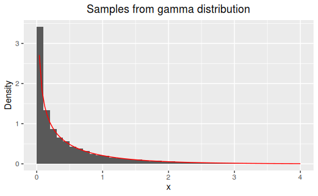

```r
# f_b1 returns the value of f in this exercise, a gamma distribution
f_b1 <- function(alpha, x) {
  gamma = (1/gamma(alpha))*x^(alpha-1)*exp(-x)
  return((gamma)*(x>0))
}

# Delete this before the files are merges, only for help
# alpha: parameter alpha
# n: number of samples to generate
# dist1 returns a vector of random numbers from the distribution g
dist1 <- function(alpha, n) {
   u <- runif(n)
   L = u<ca(alpha)/alpha
   res = c(1:n)*0
   res[L] = (u[L]*alpha/ca(alpha))^(1/alpha)
   res[!L] = -log((1-u[!L])/ca(alpha))
   return(list(res,u))
}

# g_test is the theoretical function to test the algorithm with
g_test = function(alpha, x) {
  res = c(1:length(x))*0
  L = x<1&x>0
  res[L] = ca(alpha)*x[L]^(alpha-1)
  res[!L] = ca(alpha)*exp(-x[!L])
  return (res)
}

# ca: normalizing constant
ca <- function(alpha) {
  return(exp(1)*alpha/(exp(1)+alpha))
}

# acceptance_criterion returns the alpha to accept/reject in rejection sampling
acceptance_criterion <- function(alpha, x) {
  const = (exp(1)+alpha)/(gamma(alpha)*exp(1)*alpha)
  alpha = f_b1(alpha, x)/(const*g_test(alpha, x))
  return(alpha)
}

# rejection_b generates samples from f by rejection sampling
# n: number of samples to generate
# alpha: shape parameter
rejection_b <- function(alpha, n) {
  out = 1:n

  for (i in 1:n) {
    finished = 0
    while(finished==0) {
      u = runif(1)
      x = dist1(alpha, 1)[[1]]
      acceptance = acceptance_criterion(alpha, x)
      if(u <= acceptance) {
        out[i] = x
        finished = 1
      }
    }
  }
  return(out)
}


# f_testb is the theoretical function to test the algorithm with
f_testb = function(x, alpha) {
  gamma = (1/gamma(alpha))*x^(alpha-1)*exp(-x)
  return((gamma)*(x>0))
}

n = 10000
alpha = 0.5

library(ggplot2)
samples_b1 <- rejection_b(alpha, n)
x <- seq(0,4,0.001)
data_b1 <- data.frame("samples_b1"=samples_b1)
ggplot(data=data_b1, aes(data_b1$samples_b1)) +
geom_histogram(aes(y=..density..), breaks = seq(0, 4, by = 0.1)) +theme(plot.title = element_text(hjust = 0.5))+
xlim(c(0,4)) + labs(title="Samples from gamma distribution", x="x", y="Density") +
stat_function(fun = f_testb, args = list(alpha), color = "red")
```

# Task B2

## Task B2a

We can define the domain
$$C_f = \Big \{ (x_1, x_2) : 0 \le x_1 \le \sqrt{f^{*}\Big(\frac{x_2}{x_1}\Big)} \Big \}$$
where
$$f(x) =
\begin{cases}
x^{\alpha -1}e^{-x}, \quad & x> 0 \\
0, \quad & x\le 0 \\
\end{cases}$$
We now want to define some upper and lower bounds such that
$$\begin{align}
a_{-} &= \sqrt{{sup}_x f(x) } = \sqrt{f(\alpha -1)} \\
b_{+} &= \sqrt{{sup}_{x \ge 0} x^2 f(x) } = \sqrt{(\alpha +1)^2 f(\alpha +1)}\\
b_{-} &= \sqrt{{sup}_{x \le 0} x^2 f(x) } = 0
\end{align}$$

The supremum for $a_{-}$ and $b_{+}$ can easily be derived by finding extremal points of the function using differentiation and $b_{-}$ follows from $f(x) = 0$ for $x\le 0$.

# Task B2b

```r
n <- 10000
# f_gamma the kernel of a gamma function
f_gamma <- function(x, alpha){
  return (x^(alpha - 1 )*exp(-x)*(x>0))
}

alpha <- 400

# gamma_b2b2 samples from gamma distribution with large alpha
gamma_b2b2 <- function(alpha, n){
  x = 1:n
  loga = 0.5*((alpha-1)*log(alpha-1)+(1-alpha))
  logb = 0.5*((alpha+1)*log(alpha+1)-1-alpha)
  trials = 1

  for (i in 1:n){
    logx1 = loga + log(runif(1))
    logx2 = logb + log(runif(1))
    f_condition = 0.5*((alpha-1)*(logx2-logx1)-exp(logx2-logx1))
    while(logx1 > f_condition){
    logx1 = loga + log(runif(1))
    logx2 = logb + log(runif(1))
    f_condition = 0.5*((alpha-1)*(logx2-logx1)-exp(logx2-logx1))
    trials = trials + 1
    }

     x[i] = exp(logx2-logx1)
  }
  return(cbind(x, trials-1))
}


samples_b2b = gamma_b2b2(alpha, n)[,1]
hist(samples_b2b, breaks = 40, freq = FALSE, main = bquote("Histogram of gamma distribution when "~alpha == .(alpha)))
curve(dgamma(x, alpha, 1), col = "red", lwd = 2, add=TRUE)

test_tries <- function(n) {
  alpha = seq(2,2000,10)
  tryvector = 1:length(alpha)
  for (i in 1:length(alpha)) {
    tries = gamma_b2b2(alpha[i], n)[,2][1]
    tryvector[i] = tries
  }
  return(cbind(alpha, tryvector))

}

test_try = test_tries(1000)

plot(test_try[,1], test_try[,2])
```

[output not shown]

# Task B3

We want to generate $n$ samples of the gamma distribution

$$f(x) = \frac{\beta^{\alpha}}{\Gamma (\alpha)} x^{\alpha -1} e^{-\beta}$$

for $\alpha > 0$ and $\beta > 0$. We use that $Y = \frac{X}{\beta}$ is Gamma($\alpha$, $\beta$) distributed if $X$ is Gamma($\alpha$) distributed. To show this, use the moment generating function of $Y$ and the properties of moment generating functions.

$$M_Y(t) = M_X\bigg(\frac{t}{\beta}\bigg) = \bigg(1-\frac{t}{\beta}\bigg)^{-\alpha}$$
which we recognize as the MGF of a Gamma($\alpha$, $\beta$) variable. When $\alpha = 1$, we recognize this as the MGF of an Exponential($\beta$) distribution, so therefore we can sample from the exponential distribution in this case. We use the rejection sampling algorithm for $\alpha \in (0,1)$ and the ratio of uniforms algorithm for $\alpha>1$.

```r
# Delete this before merging the files, only for help
# n: number of samples to generate
# rate: the rate
# expdist returns a vector with generated random numbers from exponential distribution
expdist <- function(rate, n) {
   u <- runif(n)
   x <-  -log( (1/rate)*( 1 - u))/rate
   list = list(x, u)
   return(list)
}

# gammaab samples from the gamma distribution for all values of alpha and beta > 0
gammaab <- function(alpha, beta, n) {
  if(alpha>0&&alpha<1) {
    X = rejection_b(alpha, n)/beta
  }
  else if(alpha==1) {
    X = expdist(1, n)[[1]]
  }
  else if (alpha>1) {
    X = gamma_b2b2(alpha,n)[,1]
  }
  else {
    print("alpha not valid")
    return(0)
  }
  Y = X/beta
  return(Y)
}

# theoretical_gamma is the theoretical function to test the algorithm with for alpha, beta > 0
theoretical_gamma = function(x, alpha, beta) {
  gamma = ((beta^alpha)/gamma(alpha))*x^(alpha-1)*exp(-beta*x)
  return((gamma)*(x>0))
}

alpha = 2
beta = 2
n = 10000

samples_ab <- gammaab(alpha, beta, n)
hist(samples_ab, breaks = 40, freq = FALSE, main = bquote("Histogram of samples from gamma when "~alpha == .(alpha) ~beta ==.(beta)))
curve(theoretical_gamma(x, alpha, beta), col = "red", lwd = 2, add=TRUE)
```

[output not shown]

# Task B4 a

$$f_{zv}(z,v) = \frac{v}{\Gamma(\alpha)\Gamma(\beta)}(vz)^{\alpha-1}(v(1-z))^{\beta-1}e^{-v}$$

# Task B4 b

```r
# sample_beta samples from beta(alpha, beta) distribution
# n: number of samples
sample_beta <- function(alpha, beta, n) {
  x = gammaab(alpha, 1, n)
  y = gammaab(beta, 1, n)
  z = x/(x+y)
  return(z)
}

alpha = 0.5
beta = 0.5
n = 10000
samples_beta <- sample_beta(alpha, beta, n)
hist(samples_beta, breaks = 40, freq = FALSE, main = bquote("Histogram of samples from beta when "~alpha == .(alpha) ~beta ==.(beta)))
curve(dbeta(x, alpha, beta), col = "red", lwd = 2, add=TRUE)
```

[output not shown]